# Trees for Ssd1 and Dis3-like eukaryotic proteins

Edward Wallace

17/07/2020

# Summary

This script analyses phylogenetic trees produced for Dis3/Dis3L1/Dss1/Ssd1/Dis3L2 homologs from the curated BLASTp list.

Note that file `data/BLASTp/Ssd1Dis3L2_BLASTp_76species_filteredbyhand_fullseqs_mafft_trimalstrong.fasta` has the mafft-default-aligned, reordered, trimmed sequences. We ran IQ-TREE and RaxML on those alignments. This document analyses the IQ-TREE results.

This script generates outputs: * figure 1C - figure showing phylogenetic tree of all homologs as generated by IQ-TREE. * subfamilies of Dis3, Dis3L1, Dis3L2, Dss1, and aRNIIL proteins, placed in `data/Dis3_families/`. * figure 1D - active site sequence logos of subfamilies. * Dis3L2 family is used by subsequent analyses for Figures 2 and 3, including to generate the phylogenetic tree only for the Dis3L2 family selected here.

## Load IQ-TREE results

This loads the maximum likelihood tree calculated by IQ-TREE.

```r
treefile_IQML <- here::here("data",
                            "IQ-TREE_Ssd1Dis3L2_76bh",
                            "output.treefile")
tree_IQML <- treeio::read.tree(treefile_IQML)
```

## Reroot tree to amoeba RNII-Like proteins

There are some outlying amoebozoan RNII-Like proteins (aRNIIL), which we can use as an outgroup. Plotting this large so we can see the names.

```r
amoeba_outgroup_MRCA_orig <- tidytree::MRCA(tree_IQML,"XP_003293188.1","XP_004351761.1")

tree_IQML_amoebaroot <- ape::root(tree_IQML,
                                   node=amoeba_outgroup_MRCA_orig)

amoeba_outgroup_MRCA <- tidytree::MRCA(tree_IQML_amoebaroot,
                             "XP_003293188.1","XP_004351761.1")
```

## Plot rerooted tree with ggtree defaults

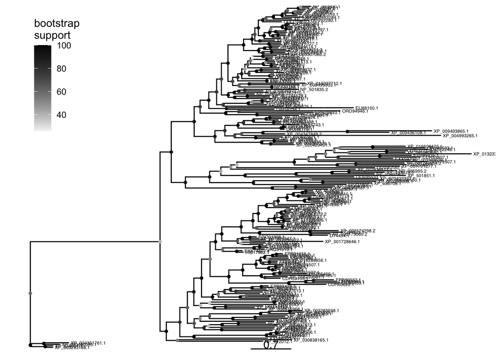

## Find Most Recent Common Ancestors (MRCA) of Dis3 sub-families

We found most recent common ancestors of the big groups: Dis3, Dis3L1, Dss1, Dis3L2.

```r
Dis3_MRCA   <- tidytree::MRCA(tree_IQML_amoebaroot,"NP_014621.1","NP_597581.1")
Dis3_offspring  <- tidytree::offspring(tree_IQML_amoebaroot,Dis3_MRCA)
Dis3L1_MRCA <- tidytree::MRCA(tree_IQML_amoebaroot,"NP_001137160.1","XP_020429451.1")
Dis3L1_offspring  <- tidytree::offspring(tree_IQML_amoebaroot,Dis3L1_MRCA)
Dis3L2_MRCA <- tidytree::MRCA(tree_IQML_amoebaroot,"O14040.1","NP_612012.1")
Dis3L2_offspring  <- tidytree::offspring(tree_IQML_amoebaroot,Dis3L2_MRCA)
Dss1_MRCA <- tidytree::MRCA(tree_IQML_amoebaroot,"NP_014014.1","XP_643697.1") #"XP_636708.1")

Dis3_clades <- c(aRNIIL = amoeba_outgroup_MRCA,
                 Dis3 = Dis3_MRCA,
                 Dis3L1 = Dis3L1_MRCA,
                 Dis3L2 = Dis3L2_MRCA,
                 Dss1 = Dss1_MRCA)

Dis3_colours <- c("0" = "grey50",
                  aRNIIL = "grey10",
                  Dis3 = "green3",
                  Dis3L1 = "cyan3",
                  Dis3L2 = "red",
                  Dss1 = "goldenrod")
```

## Plot big tree figure with names and clades

Here we use:

- `groupClade` to colour the *branches* by clade
- `geom_cladelabel` to draw the clade labels to the right of the branch
- `geom_nodepoint` to draw bootstrap support values at nodes

I did not use “equal_angle” or “unrooted” display here, because various annotations or ggtree functions did not work for those.

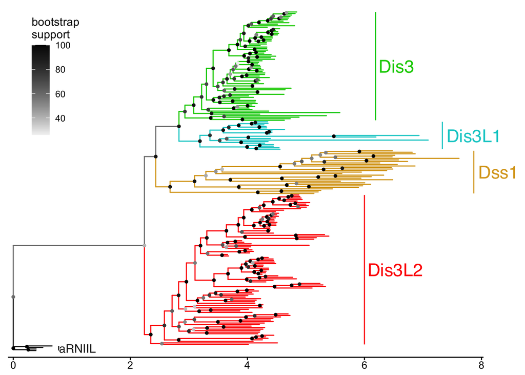

```r
ggtree(tidytree::groupClade(tree_IQML_amoebaroot,Dis3_clades),
       aes(colour=group)) +
  scale_color_manual(values=Dis3_colours,guide = FALSE) +
  geom_cladelabel(node=Dis3_MRCA, label="Dis3",
                  color=Dis3_colours["Dis3"],
                  fontsize=6,offset=0.5)  +
  geom_cladelabel(node=Dis3L1_MRCA, label="Dis3L1",
                  color=Dis3_colours["Dis3L1"],
                  fontsize=6, offset=.1)  +
  geom_cladelabel(node=Dis3L2_MRCA, label="Dis3L2",
                  color=Dis3_colours["Dis3L2"],
                  fontsize=6, offset=.5)  +
  geom_cladelabel(node=Dss1_MRCA, label="Dss1",
                  color=Dis3_colours["Dss1"],
                  fontsize=6, offset=.1)  +
  geom_cladelabel(node=amoeba_outgroup_MRCA, label="aRNIIL",
                  color=Dis3_colours["aRNIIL"],
                  fontsize=4,offset=0.1)  +
  ggnewscale::new_scale_color() +
  geom_nodepoint(aes(colour=as.numeric(label)),size=1) +
  scale_colour_gradient("bootstrap\nsupport",low="grey95",high="black") +
  coord_cartesian(clip="off") +
  scale_y_continuous(expand=c(0.02,0.02)) +
  scale_x_continuous(expand=c(0.01,0.01)) +
  theme(legend.position=c(0.1,0.8),
        plot.margin=margin(t=5,r = 40, b=5, l=5),
        axis.line.x.bottom = element_line(size=0.5,colour="black"),
        axis.ticks.x.bottom = element_line(size=0.5,colour="black"),
        axis.text.x = element_text(size=10,colour="black"))
```

## Plot tree in equal angle summary figure

We highlight S. cerevisiae Ssd1, `NP_010579.1`, with a label.

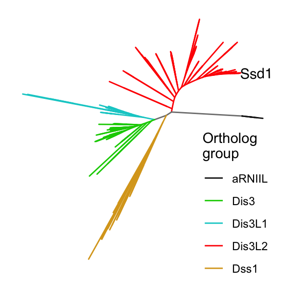

```r
ggt_Dis3groups_reroot_equalangle <-
  ggtree(tidytree::groupClade(tree_IQML_amoebaroot,Dis3_clades),
       aes(colour=group),
       layout="equal_angle") +
  scale_color_manual("Ortholog\ngroup",
                     values=Dis3_colours,
                     breaks=names(Dis3_colours)[2:6]) +
    geom_tiplab2(aes(subset=(label=="NP_010579.1")),
                 label="Ssd1", colour="black")+
  theme(legend.position=c(0.85,0.25))

ggt_Dis3groups_reroot_equalangle
```

### Extract Dis3L2 clade and plot sub-tree

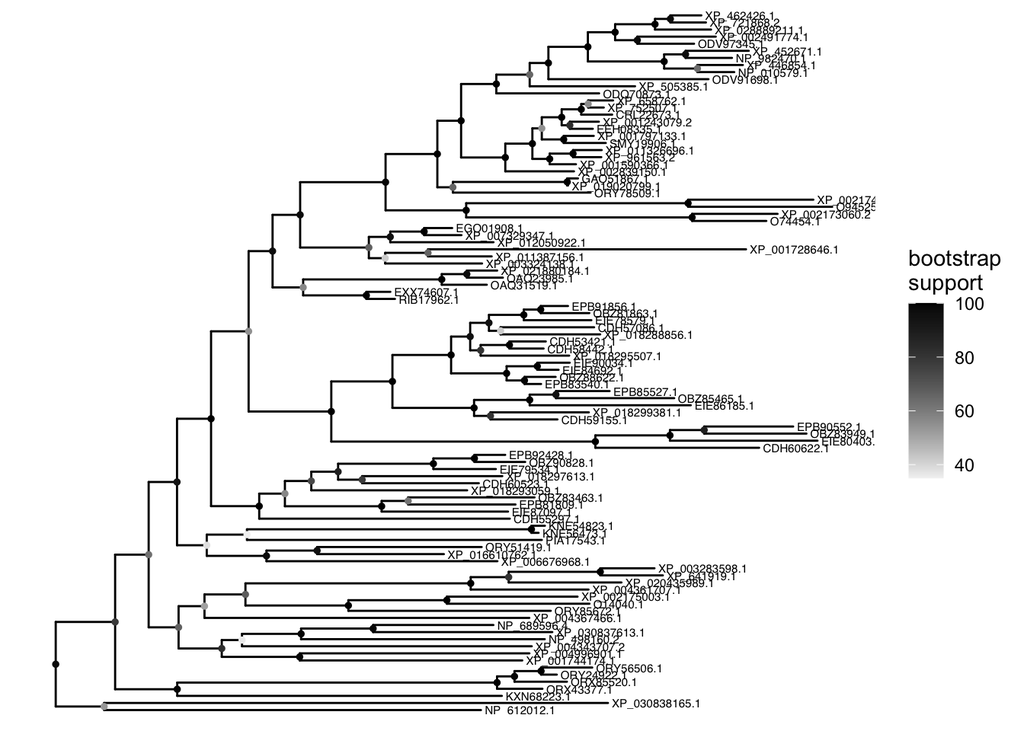

```r
tree_Dis3L2 <- treeio::tree_subset(tree_IQML_amoebaroot,Dis3L2_MRCA,levels_back=0)

ggtree(tree_Dis3L2) +
  geom_nodepoint(aes(colour=as.numeric(label)),size=1) +
  scale_colour_gradient("bootstrap\nsupport",low="grey95",high="black") +
  geom_tiplab(size=2)
```

## Get tree order

This orders the data underlying the tree in the same order as the tips are displayed in the phylogenetic tree. It uses a trick that `ggtree::ggtree` creates an internal data frame that includes the y-coordinate used to display each node, so that `dplyr::arrange(y)` arranges the data frame in display order. We then use `dplyr::pull` to extract labels/sequence ids, which we will later use to put sequences in the same order.

```r
tree_IQML_amoebaroot_data_order <-
  groupClade(tree_IQML_amoebaroot,Dis3_clades) %>%
  ggtree %>%
  .$data %>%
  filter(isTip) %>%
  arrange(y)
tree_IQML_amoebaroot_data_order
```

```
##     parent node branch.length          label  group isTip         x   y
## 1      419  191  0.1300872030 XP_003293188.1 aRNIIL  TRUE 0.3872240   1
## 2      419  192  0.1337529934    XP_638051.1 aRNIIL  TRUE 0.3908898   2
## 3      420  193  0.2721793095 XP_020430095.1 aRNIIL  TRUE 0.5044186   3
## 4      420  194  0.4306048818 XP_004351761.1 aRNIIL  TRUE 0.6628442   4
## 5      421  195  1.4764094919    NP_612012.1 Dis3L2  TRUE 4.0154168   5
## 6      421  196  1.9741379084 XP_030838165.1 Dis3L2  TRUE 4.5131453   6
## 7      294   70  1.2717503501     KXN68223.1 Dis3L2  TRUE 4.0972021   7
## 8      295   66  0.1777463743     ORX43377.1 Dis3L2  TRUE 4.2563129   8
## 9      296   69  0.2053005382     ORX85520.1 Dis3L2  TRUE 4.3522343   9
## 10     297   67  0.0613694736     ORY24922.1 Dis3L2  TRUE 4.3124158  10
## 11     297   68  0.2004460852     ORY56506.1 Dis3L2  TRUE 4.4514924  11
## 12     282   52  0.8721220830 XP_001744174.1 Dis3L2  TRUE 4.1773576  12
## 13     282   53  0.9000877896 XP_004996901.1 Dis3L2  TRUE 4.2053233  13
## 14     283   57  1.1351458984 XP_004343707.2 Dis3L2  TRUE 4.2143878  14
```

[output cut: 433 more lines]

## Output sequences in tree order for subsequent alignment of families

```r
# load the full sequences
BLASTp_76sp_fullseqs <- here::here("data",
                                   "BLASTp",
                                   "Ssd1Dis3L2_BLASTp_76species_filteredbyhand_fullseqs.fasta"
                                   ) %>%
  Biostrings::readAAStringSet()

# set the full sequence names to just be the first "word" - the sequence id
names(BLASTp_76sp_fullseqs) <-
  stringr::str_extract(names(BLASTp_76sp_fullseqs),
                       "[\\w.]+")

# define output directory
Dis3_families_dir <- here::here("data","Dis3_families")

# full sequences of Dis3 group
Dis3_ordered_fullseqs <- tree_IQML_amoebaroot_data_order %>%
  filter(group=="Dis3") %>%
  pull(label) %>%
  BLASTp_76sp_fullseqs[.]

# write to fasta file
Biostrings::writeXStringSet(Dis3_ordered_fullseqs,
                            paste0(Dis3_families_dir, "/",
                                   "Dis3_BLASTp_select_fullseqs.fasta") )

# full sequences of Dis3L1 group
Dis3L1_ordered_fullseqs <- tree_IQML_amoebaroot_data_order %>%
  filter(group=="Dis3L1") %>%
  pull(label) %>%
  BLASTp_76sp_fullseqs[.]

# write to fasta file
Biostrings::writeXStringSet(Dis3L1_ordered_fullseqs,
                            paste0(Dis3_families_dir, "/",
                                   "Dis3L1_BLASTp_select_fullseqs.fasta"))

# full sequences of Dis3L2 group
Dis3L2_ordered_fullseqs <- tree_IQML_amoebaroot_data_order %>%
  filter(group=="Dis3L2") %>%
  pull(label) %>%
  # The C. glabrata homolog "XP_446854.1" was missing from the tree data???
  # intersect(names(BLASTp_76sp_fullseqs)) %>%
  BLASTp_76sp_fullseqs[.]

Biostrings::writeXStringSet(Dis3L2_ordered_fullseqs,
                            paste0(Dis3_families_dir, "/",
                                   "Dis3L2_BLASTp_select_fullseqs.fasta"))

# full sequences of Dss1 group
Dss1_ordered_fullseqs <- tree_IQML_amoebaroot_data_order %>%
  filter(group=="Dss1") %>%
  pull(label) %>%
  BLASTp_76sp_fullseqs[.]

Biostrings::writeXStringSet(Dss1_ordered_fullseqs,
                            paste0(Dis3_families_dir, "/",
                                   "Dss1_BLASTp_select_fullseqs.fasta"))

# full sequences of aRNIIL group
aRNIIL_ordered_fullseqs <- tree_IQML_amoebaroot_data_order %>%
  filter(group=="aRNIIL") %>%
  pull(label) %>%
  BLASTp_76sp_fullseqs[.]

Biostrings::writeXStringSet(aRNIIL_ordered_fullseqs,
                            paste0(Dis3_families_dir, "/",
                                   "aRNIIL_BLASTp_select_fullseqs.fasta"))
```

## Sequence logos of active sites from subfamilies

Here we select the subsequence alignment covering the RNII/RNB-domain active site. This was selected by visual inspection of the alignment, with reference to Malecki 2013.

Note we use `Biostrings::readAAStringSet()` to load, even though it is a multiple sequence alignment.

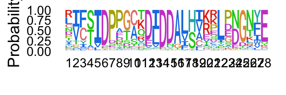

```r
BLASTp_76sp_mafftrimal <-
  here::here("data",
             "BLASTp",
             "Ssd1Dis3L2_BLASTp_76species_filteredbyhand_fullseqs_mafft_trimalstrong.fasta"
  ) %>%
  Biostrings::readAAStringSet()

# co-ordinates of start and end of active site in
activesitestart <- 664
activesiteend   <- 691

# Plot sequence logo for entire alignment
BLASTp_76sp_mafftrimal %>%
  Biostrings::subseq(start=activesitestart,end=activesiteend) %>%
  as.character() %>%
  ggseqlogo::ggseqlogo(method="probability",
                       seq_type = "aa",col_scheme="clustalx")
```

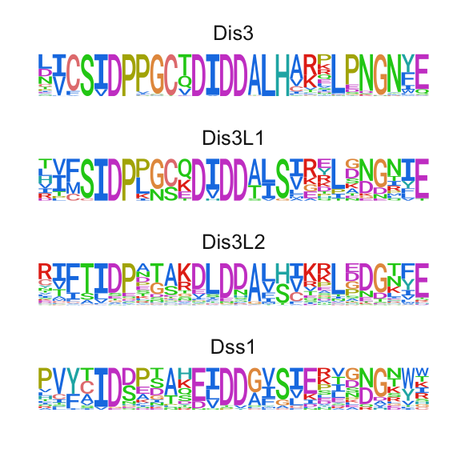

```r
collect_subseqs_ascharacter <- function(ingroup, indata, seqs) {
  # collect subsequences corresponding to a group, as character vectors
  #   ingroup : value of group field in indata
  #   indata : a tibble/data frame with columns group, label
  #   seqs : a named list of sequences, with names as in indata$label
  indata %>%
    dplyr::filter(group==ingroup) %>%
    dplyr::pull(label) %>%
    seqs[.] %>%
    as.character()
}

# Make a list, each element represents a group (Dis3 family),
# contents are the active site sequences for that group.
# we exclude aRNIIL, because it has only 4 members here
activesite_listseqbygroup <-
  sapply(names(Dis3_clades)[2:5],
         collect_subseqs_ascharacter,
         indata = tree_IQML_amoebaroot_data_order,
         seqs =
           BLASTp_76sp_mafftrimal %>%
           Biostrings::subseq(start=activesitestart,end=activesiteend) %>%
           as.character()
  )

# plot consensus sequences of active site for each group
ggs_activesitebygroup <-
  ggseqlogo::ggseqlogo(activesite_listseqbygroup,
                       method="probability",
                       scales="free",seq_type = "aa",
                       col_scheme="clustalx",ncol=1) +
  theme(axis.title.y = element_blank(),axis.text.y = element_blank(),
        axis.text.x = element_blank())

ggs_activesitebygroup
```

### Composite figure, Figure 1C and 1D of manuscript

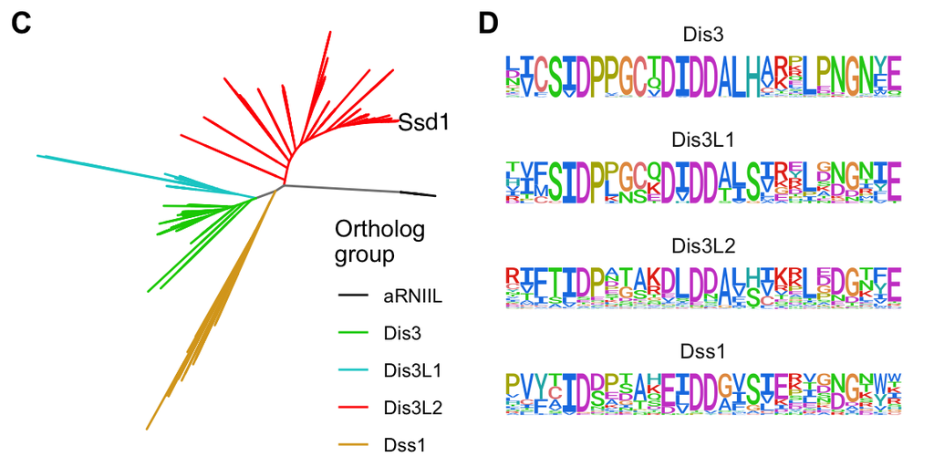

```r
figure1_Dis3cladesCD <-
  cowplot::plot_grid(ggt_Dis3groups_reroot_equalangle,
                     ggs_activesitebygroup,
                     nrow=1,labels=c("C","D"))
figure1_Dis3cladesCD
```

```r
ggsave(filename = here::here("figure","figure1_Dis3cladesCD.pdf"),
       plot = figure1_Dis3cladesCD,
       width = 6, height = 3)
```

# Session Info